# Basic Intro to R

Andrew Barr

## Welcome

Welcome to the interactive introduction to R exercise. You have 40 minutes to work on this….feel free to talk to your breakout group members! You aren’t alone!

You will type R commands directly into your browser in this tutorial. Later we will use R on your own personal computer.

## Interactive R

### A very complicated calculator

The most basic way to interact with R is to use it like a calculator. Type `2 + 2` and then click the ‘Run Code’ button. Instead of clicking the button, you can also hit CTRL + Enter (Windows) or Command + Enter (Mac). Later, when you run R code on your own computer, you can just hit Enter.

You should see your result appear, saying `[1] 4`. Don’t worry about the `[1]` part yet (we will get there). The `4` is the result of the calculation you asked R to do.

### Congrats!

You are now using R, and you know the answer to 2 + 2 ;-)

For this tutorial you will enter commands directly into your browser. Later, we will open the R interpreter on your computer and and we will see how you can save a complicated series of commands to a script file and execute them automatically.

## Assignment

### Storing values for later

Sometimes it is useful to assign the results of computations to a named variable that we will use later.

We can create a named variable using the `<-` assignment operator. (This is the ‘less than’ symbol followed by the ‘hyphen’ symbol).

It is called ‘assignment’ because you are assigning a specific value to a specific named object. Notice that the assignment operator looks like an arrow, and the arrow points towards the name which is being assigned.

**Note**: It is technically possible to use the `=` symbol for assignment, but this is bad form, and will incite the wrath of R purists on the internet. Get used to typing the `<-` symbol.

```r
myVariable <- 2 + 3
```

Now the result from this computation is assigned to `myVariable` and saved for later use. Later, we can call this variable like so:

```r
myVariable * myVariable
```

```
## [1] 25
```

### Challenge

Use the interpreter below to assign the value 17 to the variable `apple`, and assign the value 63 to the variable `banana`, then use the interpreter to divide `banana` by `apple`. Note: you can type multiple lines of code in the box before you hit “Run Code” to actually do the calculations.

Note: the `#` character in the box below signifies a comment meant for a human being to read. R will ignore anything on a line that begins with the `#` character

```r
# type your code here
```

The answer should be 3.705882 if you did this correctly.

## Are you lost?

Talk to some members of your small group! You can share screens, chat, etc within the breakout room, so chances are somebody can help you!

## Atomic vectors

### The basics

An atomic vector is a series of values stored together in a single object.

You can create a vector using the `c()` function (**c** stands for **combine**).

**Note**: you can only store a single type of data in a vector (e.g. numeric data or text data).

For example, here are some (fake) measurements of human tibiae and femora, in millimeters. Hit the “Run Code” button to see what happens.

```r
femur <- c(450.8,444.8,415.1,487.3,349,459.5,431.7,454.1,420.6,387.2)
tibia <- c(337.7,336.7,333.9,356.6,356.8,361.7,373.3,338.4,379.4,370.9)
print(femur)
```

```
##  [1] 450.8 444.8 415.1 487.3 349.0 459.5 431.7 454.1 420.6 387.2
```

```r
print(tibia)
```

```
##  [1] 337.7 336.7 333.9 356.6 356.8 361.7 373.3 338.4 379.4 370.9
```

Notice that after I created the vectors using the `c()` function, I have used the `print()` command to print out the contents of the `femur` and `tibia` vectors. If I didn’t include those lines, then R would have silently created the vectors, without printing the values to the screen.

Note: on your own computer, instead of using the `print()` command, you can just type the name of an existing variable and press enter. By default, R will print the current value of the requested variable.

### Challenge

use the `c()` function to create a vector called `DMV` containing the words “DC”, “Maryland”, and “Virginia”. Then use the `length()` function to see how many elements are in the `DMV` vector that you just created.

```r
## Type your code here
```

```r
DMV <- c("DC", "Maryland", "Virginia")
length(DMV)
```

```
## [1] 3
```

### Vectorization

Many of the basic functions and operations in R are **vectorized**, meaning that they operate on all elements of a vector in sequence.

To sum the elements of two vectors together, you can just add them like they are numbers, because the `+` function is vectorized.

This is one of the fundamental advantages of R, which you will grow to appreciate over time (I promise)!

### Challenge

If we wanted to calculate an approximate leg length for each individual in our dataset, we can just add the `femur` and `tibia` vectors together using the `+` symbol. Try it below!

```r
## Type your answer here
```

You will see that the result of adding these two variables is the summed tibia and femur length for each individual. Under the hood, R has added the vectors element-by-element, summing the first tibia length with the first femur length, the second tibia length with the second femur length, and so on.

### What happens when I mix numbers with text in a vector??

Add a new line to the code below to see what happens if you try to add `badnews` + `tibia`? Don’t forget to click “Run Code” after you add your new line.

```r
badnews <- c(21,22,23,24,25,26,27,28,29,"thirty")
```

### A real stumper

What kind of data is contained in the ‘badnews’ vector?

Answer: Text data

Only one kind of data can exist in an atomic vector, so R converts everything to text.

## Accessing values within a vector

### Indexing

Vectors can be **indexed** with brackets `[]` to get a subset of values.

Recall the `femur` variable, which contains 10 distinct numbers in it.

```r
femur
```

```
##  [1] 450.8 444.8 415.1 487.3 349.0 459.5 431.7 454.1 420.6 387.2
```

If I type `femur[2]` then I get back only the second element in the `femur` vector.

```r
femur[2]
```

```
## [1] 444.8
```

### getting more than one value back

You can also request back more than one value. Here are two equivalent ways to get the second through the fifth elements of the `femur` vector.

```r
femur[c(2,3,4,5)]
```

```
## [1] 444.8 415.1 487.3 349.0
```

```r
femur[2:5]
```

```
## [1] 444.8 415.1 487.3 349.0
```

```r
#note, the : symbol is a quick way to make a series of integers
```

### Challenge

In a single line of code, extract the first, fifth, and ninth element of the `tibia` vector.

use the `c()` function to combine multiple integers, and index using the brackets as above `[]`

### Negative Indexing

When you use negative indices, then the referenced elements are **removed** from the resulting vector.

```r
dwarves <- c("Dopey", "Gimli", "Larry")
dwarves[-3] #real dwarves
```

```
## [1] "Dopey" "Gimli"
```

**Remember**: comments using the octothorpe (AKA the hashtag #) are for meat people to read, not computers.

### Challenge

Remove the 1st, 5th and 9th elements from `femur`

## Logical Tests

### Making assertions

Logical tests are assertions that R evaluates as either `TRUE` or `FALSE`.

For instance, you might assert that “1 plus 1 equals 10 minus 8”?

In R that looks like:

```r
1 + 1 == 10 - 8
```

```
## [1] TRUE
```

R tells us that this is `TRUE`.

Note the double equals symbol, which means something different than a single equals symbol.

### It ain’t just text

Note that `TRUE` and `FALSE` are special values in R. They are not just text variables. Only text variables require quotation marks, so when you type `TRUE` and `FALSE` you don’t need quotes. Just like EVERYTHING in R, capitalization matters. Try this on for size:

```r
"True" == TRUE
```

```
## [1] FALSE
```

However, R will automatically convert the text strings “TRUE” and “FALSE” to their special logical values `TRUE` and `FALSE`, so you get this.

```r
"TRUE" == TRUE
```

```
## [1] TRUE
```

### The logical operators

The logical operators are:

- `==` is equal to
- `!=` does not equal
- `>` greater than
- `<` less than
- `>=` greater than or equal to
- `<=` less than or equal to

### Logical indexing

Like most things in R, logical tests work on vectors.

Remember `femur` from before?

```r
femur
```

```
##  [1] 450.8 444.8 415.1 487.3 349.0 459.5 431.7 454.1 420.6 387.2
```

Lets find out which values are greater than 450 mm. Note that we are asserting that every value of the `femur` vector is larger than 450. R goes through element by element and reports whether our assertion is TRUE or FALSE. Don’t forget to click “Run Code” to see the result.

```r
femur > 450
```

```
##  [1]  TRUE FALSE FALSE  TRUE FALSE  TRUE FALSE  TRUE FALSE FALSE
```

### Logical indexing

This becomes really useful when you want a subset of values from a vector that meet some condition

To get **only** the values of `femur` that are greater than 450, we can use a logical (AKA boolean) vector.

```r
femur[femur > 450]
```

```
## [1] 450.8 487.3 459.5 454.1
```

What happened here? You passed a vector of `TRUE` and `FALSE` values inside the brackets `[]`. R returned back a shorter vector, which contains onl ONLY those cases where the value was `TRUE`. Notice that since we haven’t assigned this resulting vector a name, it is just printed and R then forgets about it.

Modify the above code and assign the subset of femora that are less than 450mm to a new vector called `smallFemora`.

### Summing logical vectors

Its a handy trick to calculate the sum of a logical vector using the `sum()` function. When you do this, R treats `TRUE` as 1 and `FALSE` as 0. So if I want to count the number of femora greater than 450mm I can just to this:

```r
sum(femur>450)
```

```
## [1] 4
```

This returns the number 4, which is the number of `TRUE` values in the logical vector we create when we assert `femur>450`. In plain English, there are 4 femora in our vector that are longer than 450 mm.

### Getting all fancy with logical indexing

You can also pass complicated logical tests using the AND operator `&` or the logical OR operator `|`

```r
femur[femur > 450 & femur < 460]
```

```
## [1] 450.8 459.5 454.1
```

```r
femur[femur > 450 | tibia < 330]
```

```
## [1] 450.8 487.3 459.5 454.1
```

## Assignment & Indexing

### Replacing elements

You can also use `<-` to replace particular elements in a vector. Suppose we have a vector of primates:

```r
primates <- c("gorilla", "gibbon", "langur", "gibbon", "gorilla")
primates
```

```
## [1] "gorilla" "gibbon"  "langur"  "gibbon"  "gorilla"
```

We can replace the third element of this vector like so:

```r
primates[3] <- "bushbaby"
primates
```

```
## [1] "gorilla"  "gibbon"   "bushbaby" "gibbon"   "gorilla"
```

### Challenge

Replace all instances of ‘gorilla’ with ‘chimpanzee’ in the `primates` vector, making use of logical indexing.

```r
## your code here
```

```r
primates[primates=="gorilla"] <- "chimpanzee"
primates
```

```
## [1] "chimpanzee" "gibbon"     "bushbaby"   "gibbon"     "chimpanzee"
```

## Factors

A factor is a special type of vector for storing categorical data. You can use the `factor()` function to turn a normal vector into a factor.

```r
vectorpets <- c("cat", "cat", "dog", "pony", "dog", "dog")
pets <- factor(vectorpets)
pets
```

```
## [1] cat  cat  dog  pony dog  dog
## Levels: cat dog pony
```

R will now treat this differently from other vectors.

These come in useful later on, when we want to summarize by different factor levels (i.e. the unique values a factor can take on).

### Ordered factors

By default, R assumes the order of the levels in your factor is alphabetical.

You can change this by replacing the normal factor `pets` with a new *ordered* factor

```r
pets <- ordered(pets, levels=c("pony", "dog", "cat"))
pets
```

```
## [1] cat  cat  dog  pony dog  dog
## Levels: pony < dog < cat
```

This is useful mostly when you want to change how factors get plotted graphically.

## Data Frames

### The workhorse data structure of R

Data frames store related vectors of data together in a single object.

They are analogous to a spreadsheet:

> - each row corresponds to an individual (e.g., specimen, species)
> - each column corresponds to some observation about that individual

### Accessing data in a dataframe

There are two basic ways to access data within a dataframe

`$` is used to access a named column within an dataframe

The `[rownumber, columnnumber]` syntax is used to identify the index number of the row and column desired

### iris

To see this in action, we will use the data frame `iris`, which is built in to R (if you type `iris` in R on your computer and hit enter, you will see that it is already a data frame that exists!)

As you will see, this dataframe consists of measurements of the sepal and petal of iris flowers from several different species.

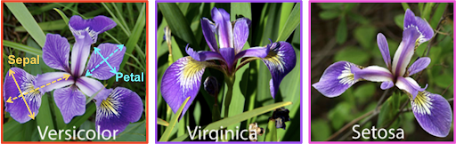

We can use the `head()` function to get a glimpse of the dataset. By default, `head()` shows the first few rows of a data frame. You can see that the columns of a dataframe each have a name.

```r
head(iris)
```

```
##   Sepal.Length Sepal.Width Petal.Length Petal.Width Species
## 1          5.1         3.5          1.4         0.2  setosa
## 2          4.9         3.0          1.4         0.2  setosa
## 3          4.7         3.2          1.3         0.2  setosa
## 4          4.6         3.1          1.5         0.2  setosa
## 5          5.0         3.6          1.4         0.2  setosa
## 6          5.4         3.9          1.7         0.4  setosa
```

### Getting data by named column

You can request a single named column using the `$` symbol. Be very careful with your capitaliation and be sure to include the `.` in `Petal.Length`! R is super duper picky about spelling and capitalization.

```r
iris$Petal.Length
```

```
##   [1] 1.4 1.4 1.3 1.5 1.4 1.7 1.4 1.5 1.4 1.5 1.5 1.6 1.4 1.1 1.2 1.5 1.3 1.4
##  [19] 1.7 1.5 1.7 1.5 1.0 1.7 1.9 1.6 1.6 1.5 1.4 1.6 1.6 1.5 1.5 1.4 1.5 1.2
##  [37] 1.3 1.4 1.3 1.5 1.3 1.3 1.3 1.6 1.9 1.4 1.6 1.4 1.5 1.4 4.7 4.5 4.9 4.0
##  [55] 4.6 4.5 4.7 3.3 4.6 3.9 3.5 4.2 4.0 4.7 3.6 4.4 4.5 4.1 4.5 3.9 4.8 4.0
##  [73] 4.9 4.7 4.3 4.4 4.8 5.0 4.5 3.5 3.8 3.7 3.9 5.1 4.5 4.5 4.7 4.4 4.1 4.0
##  [91] 4.4 4.6 4.0 3.3 4.2 4.2 4.2 4.3 3.0 4.1 6.0 5.1 5.9 5.6 5.8 6.6 4.5 6.3
## [109] 5.8 6.1 5.1 5.3 5.5 5.0 5.1 5.3 5.5 6.7 6.9 5.0 5.7 4.9 6.7 4.9 5.7 6.0
## [127] 4.8 4.9 5.6 5.8 6.1 6.4 5.6 5.1 5.6 6.1 5.6 5.5 4.8 5.4 5.6 5.1 5.1 5.9
## [145] 5.7 5.2 5.0 5.2 5.4 5.1
```

### Getting data by row and column number

You can specify a specific row and column number to get back a single value. Here we are asking for the 1st row and the 3rd column.

The order is always row number first, then a comma, then the column number.

```r
iris[1,3]
```

```
## [1] 1.4
```

### Challenge

```r
## type your code here
```

### Getting a whole row of data

If you leave a blank before or after the comma, then R will give you all the rows or all the columns (depending on which one you leave blank).

Leving it blank means you want all of whatver you left blank. So this line of code says “give me the first row, and all of the columns of the `iris` dataframe.”

```r
iris[1, ]
```

```
##   Sepal.Length Sepal.Width Petal.Length Petal.Width Species
## 1          5.1         3.5          1.4         0.2  setosa
```

### More than one way to crack a hickry nut

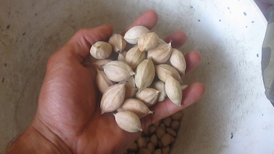

Forgive the folksy expression drawn from my Kentucky forbears, but note that there are often many ways to do the same thing in R.

To get just the species column from the `iris` data frame, both of the lines of code below are identical. This works because the fifth column of the `iris` dataframe is named ‘Species’. Make sense?

```r
iris$Species
```

```
##   [1] setosa     setosa     setosa     setosa     setosa     setosa
##   [7] setosa     setosa     setosa     setosa     setosa     setosa
##  [13] setosa     setosa     setosa     setosa     setosa     setosa
##  [19] setosa     setosa     setosa     setosa     setosa     setosa
##  [25] setosa     setosa     setosa     setosa     setosa     setosa
##  [31] setosa     setosa     setosa     setosa     setosa     setosa
##  [37] setosa     setosa     setosa     setosa     setosa     setosa
##  [43] setosa     setosa     setosa     setosa     setosa     setosa
##  [49] setosa     setosa     versicolor versicolor versicolor versicolor
##  [55] versicolor versicolor versicolor versicolor versicolor versicolor
##  [61] versicolor versicolor versicolor versicolor versicolor versicolor
##  [67] versicolor versicolor versicolor versicolor versicolor versicolor
##  [73] versicolor versicolor versicolor versicolor versicolor versicolor
##  [79] versicolor versicolor versicolor versicolor versicolor versicolor
##  [85] versicolor versicolor versicolor versicolor versicolor versicolor
##  [91] versicolor versicolor versicolor versicolor versicolor versicolor
##  [97] versicolor versicolor versicolor versicolor virginica  virginica
## [103] virginica  virginica  virginica  virginica  virginica  virginica
## [109] virginica  virginica  virginica  virginica  virginica  virginica
## [115] virginica  virginica  virginica  virginica  virginica  virginica
## [121] virginica  virginica  virginica  virginica  virginica  virginica
## [127] virginica  virginica  virginica  virginica  virginica  virginica
## [133] virginica  virginica  virginica  virginica  virginica  virginica
## [139] virginica  virginica  virginica  virginica  virginica  virginica
## [145] virginica  virginica  virginica  virginica  virginica  virginica
## Levels: setosa versicolor virginica
```

```r
iris[,5]
```

```
##   [1] setosa     setosa     setosa     setosa     setosa     setosa
##   [7] setosa     setosa     setosa     setosa     setosa     setosa
##  [13] setosa     setosa     setosa     setosa     setosa     setosa
##  [19] setosa     setosa     setosa     setosa     setosa     setosa
##  [25] setosa     setosa     setosa     setosa     setosa     setosa
##  [31] setosa     setosa     setosa     setosa     setosa     setosa
##  [37] setosa     setosa     setosa     setosa     setosa     setosa
##  [43] setosa     setosa     setosa     setosa     setosa     setosa
##  [49] setosa     setosa     versicolor versicolor versicolor versicolor
##  [55] versicolor versicolor versicolor versicolor versicolor versicolor
##  [61] versicolor versicolor versicolor versicolor versicolor versicolor
##  [67] versicolor versicolor versicolor versicolor versicolor versicolor
##  [73] versicolor versicolor versicolor versicolor versicolor versicolor
##  [79] versicolor versicolor versicolor versicolor versicolor versicolor
##  [85] versicolor versicolor versicolor versicolor versicolor versicolor
##  [91] versicolor versicolor versicolor versicolor versicolor versicolor
##  [97] versicolor versicolor versicolor versicolor virginica  virginica
## [103] virginica  virginica  virginica  virginica  virginica  virginica
## [109] virginica  virginica  virginica  virginica  virginica  virginica
## [115] virginica  virginica  virginica  virginica  virginica  virginica
## [121] virginica  virginica  virginica  virginica  virginica  virginica
## [127] virginica  virginica  virginica  virginica  virginica  virginica
## [133] virginica  virginica  virginica  virginica  virginica  virginica
## [139] virginica  virginica  virginica  virginica  virginica  virginica
## [145] virginica  virginica  virginica  virginica  virginica  virginica
## Levels: setosa versicolor virginica
```

### Creating a new column with `$`

You can also create new columns in a dataframe using the `$` operator.

There is no columm names `Petal.Area`

```r
iris$Petal.Area
```

### Challenge

Add a new column called `Petal.Area` by multiplying `Petal.Length` and `Petal.Width` and assigning the product to `iris$Petal.Area`

```r
# your answer here
```

```r
iris$Petal.Area <- iris$Petal.Length * iris$Petal.Width
head(iris)
```

```
##   Sepal.Length Sepal.Width Petal.Length Petal.Width Species Petal.Area
## 1          5.1         3.5          1.4         0.2  setosa       0.28
## 2          4.9         3.0          1.4         0.2  setosa       0.28
## 3          4.7         3.2          1.3         0.2  setosa       0.26
## 4          4.6         3.1          1.5         0.2  setosa       0.30
## 5          5.0         3.6          1.4         0.2  setosa       0.28
## 6          5.4         3.9          1.7         0.4  setosa       0.68
```

Note: Adding a calculated column like this is less error prone and more repeatable than doing it in Excel…..

You should store the data in a spreadsheet, and then manipulate it in R.

## Functions

### Where the rubber hits the road

Functions are the heart of R.

A function is just a series of commands that is assigned a name.

Functions:

> - accept **arguments**
> - perform a series of commands using the argument values
> - **return** a single object.

You can create your own functions (and you will!) but there are many hundreds of pre-defined functions available for your use.

### Which function do I use?

**A huge part of the learning curve of R is learning which functions exist, which is why they invented google dot com!**

Remember, the first rule of using R is JFGIS. Just F*cking Google It, Seriously!!

If you are doing something and thinking “I bet there is a function to do this in R” you are probably correct, and search engines will help you find it!

You have already used several functions in this tutorial:

- `c()` - combines elements into a vector
- `head()` - shows the first few rows of a data frame
- `factor()` - turns a vector into a categorical variable (i.e. a factor)

### Calling Functions

You call a function by typing its name, followed by parentheses containing 0 or more **arguments**. When you call a function, you should not include a space between the name of the function and the opening parenthesis.

So this is good:

- `function(x)`

And this is bad:

- `function (x)`

### Arguments

Arguments are the way you pass data and/or options to a function.

For example, the `paste()` function simply pastes together its arguments into a single text string. Try running this code to see the result of the `paste()` function

```r
part1 <- "The quick brown fox"
part2 <- "jumped over the lazy dog."
paste(part1, part2)
```

```
## [1] "The quick brown fox jumped over the lazy dog."
```

### Getting help with function arguments

You can see all the arguments and default values for any function using the `?` operator. So to see the help file for the `paste()` function we can do the following. Help files are easier to read when running R on your computer than they appear here in the tutorial.

```r
?paste
```

You will see that the help file has a list of the arguments, with a description of what they do in the context of the function.

Note: the help files in R are terse. Learning how to read and understand them is a skill you will build over time.

[output not shown]